# assignment3

Eduardo Guzman

10/5/2021

## Part 1 - Wrangling Data

### Loading the data

```r
college_data = college_recent_grads
```

### 1. Which majors have the lowest unemployment rate?

```r
lowest_unemployment <- college_data %>%
  mutate(unemployment_rate_percentage = round((unemployment_rate * 100), 2)) %>%
  select(major, unemployment_rate_percentage, unemployment_rate) %>%
  arrange(unemployment_rate_percentage)

table <- lowest_unemployment %>%
  select(major, unemployment_rate_percentage)

print(table)
```

```
## # A tibble: 173 x 2
##    major                                      unemployment_rate_percentage
##    <chr>                                                             <dbl>
##  1 Mathematics And Computer Science                                   0
##  2 Military Technologies                                              0
##  3 Botany                                                             0
##  4 Soil Science                                                       0
##  5 Educational Administration And Supervision                         0
##  6 Engineering Mechanics Physics And Science                          0.63
##  7 Court Reporting                                                    1.17
##  8 Mathematics Teacher Education                                      1.62
##  9 Petroleum Engineering                                              1.84
## 10 General Agriculture                                                1.96
## # ... with 163 more rows
```

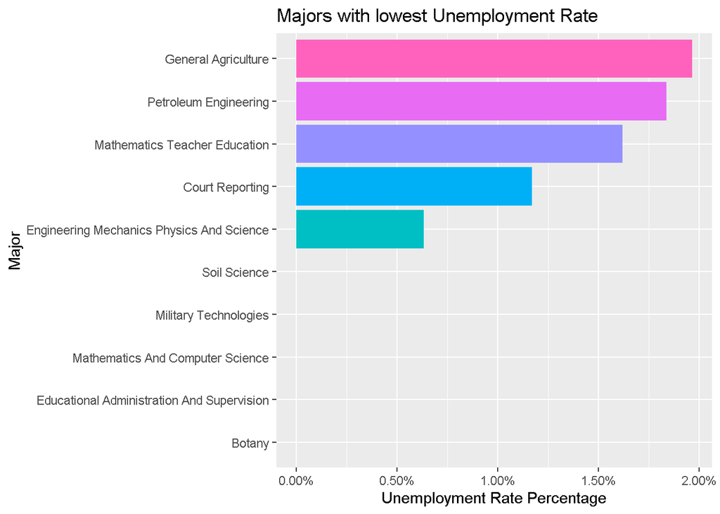

```r
lowest_unemployment%>%
  mutate(major = fct_reorder(lowest_unemployment$major, lowest_unemployment$unemployment_rate, min))%>%
  head(lowest_unemployment, n = 10)%>%
  ggplot(aes(x= unemployment_rate, y = major, fill = major))+
  geom_col(show.legend = FALSE)+
  labs(y = "Major", x = "Unemployment Rate Percentage", title = "Majors with lowest Unemployment Rate") +scale_x_continuous(labels = scales::percent)
```

### 2. How do the distributions of median income compare across major categories? Display just the top 5 in a visual.

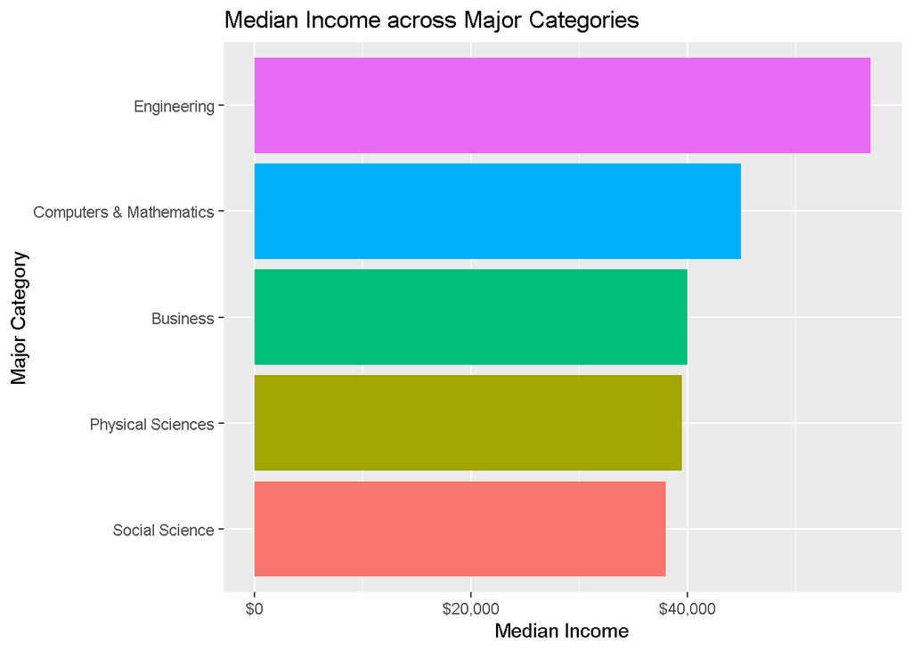

```r
viz <- college_data %>%
  group_by(major_category) %>%
  summarize(median_median = median(median))%>%
  mutate(major_category = fct_reorder(major_category, median_median, max) )%>%
  arrange(desc(median_median))%>%
  head(median_median, n=5)

viz %>%
  ggplot(aes(x = median_median, y= major_category, fill= major_category))+
  geom_col(show.legend = FALSE)+
  labs(x = "Median Income", y = "Major Category", title = "Median Income across Major Categories")+
  scale_x_continuous(labels = dollar_format())
```

### 3. Which major category is the least popular in this dataset? Show the top 10 least popular majors.

```r
college_data %>%
  select(major, rank) %>%
  arrange(desc(rank)) %>%
  head(rank, n = 10)
```

```
## # A tibble: 10 x 2
##    major                                          rank
##    <chr>                                         <int>
##  1 Library Science                                 173
##  2 Counseling Psychology                           172
##  3 Clinical Psychology                             171
##  4 Educational Psychology                          170
##  5 Zoology                                         169
##  6 Composition And Rhetoric                        168
##  7 Drama And Theater Arts                          167
##  8 Other Foreign Languages                         166
##  9 Early Childhood Education                       165
## 10 Communication Disorders Sciences And Services   164
```

## Part 2 - Ethics in Business Analytics

### 1. Association of Computing Machinery’s Code of Ethics and Professional Conduct

#### 3.5 Create opportunities for members of the organization or group to grow as professionals:

Bryan works for Code Inc, a company that specializes in writing software for advertisement companies. Bryan has developed a code that can be downloaded by users to help find accurate matches for their shopping lists using a history of the users purchases. During a meeting with his supervisors Bryan introduces his new idea, they decide that this type of software could potentially violate users privacy and reject his idea. Due to this Bryan felt he was not given an opportunity to learn how he could improve his software and goes on without obtaining any new knowledge. This left a potentially good software idea go to waste without a chance to have it improved which would have given Bryan a big boost to his portfolio. Code Inc. has violated section 3.5 of the Association of Computing Machinery’s Code of Ethics and Professional Conduct.. Bryan’s advisors should have programs in place to teach him and his coworkers about the consequences of developing code that could be in violation of users’ privacy. Without programs or learning seminars many computing professionals can go on to make mistakes that could put companies at risk as well as their careers.

### 2. American Statistical Association’s Ethical Guidelines for Statistical Practice

#### A. Professional Integrity and Accountability (2,5):

Michael is a statistician working for Code Inc. he comes into work one day and receives a request from a supplement company to use data to support the positive effects of a new drug that will be used for weight loss. The company has reached out to Code Inc. to help with advertisements for this new product and offers Michael data that is clearly biased in favor of the new drug. Michael is offered a bonus by his supervisors if he makes this deal happen at any cost. Thinking that he will not be in the wrong, Michael uses the biased data and manages a deal with the supplement company to receive his bonus. This instance is a clear violation of section “A” of the Ethical Guidelines for Statistical practice, Michael did not employ the proper analytical methods to support the new drug, new clients are going to buy this product without knowing all of the risks since he did not perform a proper analysis of data regarding the ingredients of the drug. Also, Michael failed to disclose the bonus that was offered to him which created a clear conflict of interest which is unacceptable.

## Part 3 - Regression and Predictions

### Loading the data

```r
vehicle <- read.csv("vehicles-1.csv")
```

```r
set.seed(1)

split <- initial_split(vehicle, prop = 0.6)

training_vehicles <- training(split)
testing_vehicles <- testing(split)

training_model_1 <- lm(vehicle$MPG ~ vehicle$Vweight+vehicle$Horse_Power, data = vehicle)
summary(training_model_1)
```

```
##
## Call:
## lm(formula = vehicle$MPG ~ vehicle$Vweight + vehicle$Horse_Power,
##     data = vehicle)
##
## Residuals:
##      Min       1Q   Median       3Q      Max
## -11.1590  -2.7553  -0.3604   2.3463  16.2102
##
## Coefficients:
##                       Estimate Std. Error t value             Pr(>|t|)
## (Intercept)         45.7527577  0.7915331  57.803 < 0.0000000000000002 ***
## vehicle$Vweight     -0.0058657  0.0005048 -11.620 < 0.0000000000000002 ***
## vehicle$Horse_Power -0.0459447  0.0112243  -4.093            0.0000516 ***
## ---
## Signif. codes:  0 '***' 0.001 '**' 0.01 '*' 0.05 '.' 0.1 ' ' 1
##
## Residual standard error: 4.263 on 393 degrees of freedom
## Multiple R-squared:  0.703,  Adjusted R-squared:  0.7014
## F-statistic:   465 on 2 and 393 DF,  p-value: < 0.00000000000000022
```

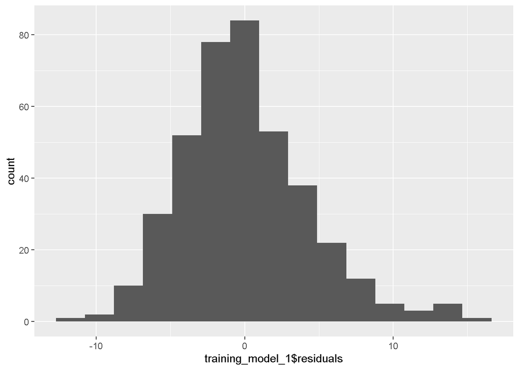

```r
ggplot(data = training_model_1) +
  aes(x = training_model_1$residuals)+
  geom_histogram(bins = 15)
```

The count of negative residuals is greater than the positive residuals. However, the majority of the counts of the residuals are near 0. Which means that the model has a good fit.